# Projet statistique avec R : TP2

DIOP Ousseynou (ISEP 3)

2024-04-13

# 1 Bibliothèques

```r
library(dplyr)
library(haven)
library(readxl)
library(ggplot2)
library(expss)
library(kableExtra)
library(gtsummary)
```

# 2 Recodage et labelisation

## 2.1 Description de la base

voir tp

## 2.2 Importation et mise en forme

### 2.2.1 Importation de la base

```r
way <- getwd() #chemin relatif de notre base de données
past <- paste0(way,"/Base TP2.xlsx") #chemin complet pour acceder a la base de données
base_tp2 <- read_xlsx(past)
base_tp2 <- data.frame(base_tp2)
```

### 2.2.2 Nombre de ligne et nombre de colonne

```r
dim(base_tp2) # Dim donne le nombre de ligne et de colonne respectivement
```

```
## [1] 53 30
```

```r
str(base_tp2) # caractéristique de la base
```

```
## 'data.frame':    53 obs. of  30 variables:
##  $ region          : num  5 5 2 1 5 3 3 2 2 4 ...
##  $ departement     : num  53 53 22 12 52 31 32 22 22 41 ...
##  $ sexe            : num  2 1 2 1 2 1 2 1 1 1 ...
##  $ age             : num  35 50 35 25 60 36 25 56 55 80 ...
##  $ sit_mat         : num  1 1 1 1 1 1 1 1 1 1 ...
##  $ si_chef_men     : num  1 2 1 3 1 1 3 2 2 2 ...
##  $ ethnie          : num  10 1 1 3 77 3 3 1 1 2 ...
##  $ occupation      : num  22 1 1 22 1 1 15 1 1 1 ...
##  $ formation       : num  4 1 3 5 3 99 1 1 1 1 ...
##  $ niveau_alphabs  : num  NA 0 NA NA NA NA 1 0 0 0 ...
##  $ types_varietes  : chr  "2" "1" "1" "1" ...
##  $ types_varietes_1: num  0 1 1 1 1 1 1 1 0 1 ...
##  $ types_varietes_2: num  1 0 0 0 0 1 0 0 1 0 ...
##  $ criteres_var    : chr  "1 12 13" "1 4 6 7 11 13" "1 5 6" "1 4 6 7 14 15" ...
```

[output cut: 16 more lines]

## 2.3 Recodage et labelisation

### 2.3.1 Labélisation des variables

```r
# Nous allons utiliser apply_label de la bibliotheque expss pour labéliser les variables
colnames(base_tp2)# les différentes variables de la base
```

```
##  [1] "region"           "departement"      "sexe"             "age"
##  [5] "sit_mat"          "si_chef_men"      "ethnie"           "occupation"
##  [9] "formation"        "niveau_alphabs"   "types_varietes"   "types_varietes_1"
## [13] "types_varietes_2" "criteres_var"     "criteres_var_1"   "criteres_var_2"
## [17] "criteres_var_3"   "criteres_var_4"   "criteres_var_5"   "criteres_var_6"
## [21] "criteres_var_7"   "criteres_var_8"   "criteres_var_9"   "criteres_var_10"
## [25] "criteres_var_11"  "criteres_var_12"  "criteres_var_13"  "criteres_var_14"
## [29] "criteres_var_15"  "criteres_var_16"
```

```r
base_tp2 <- base_tp2%>%
  apply_labels (region="region", sexe= "sexe",age="age",sit_mat="Situation matrimoniale", si_chef_men="Statut dans le menage", ethnie="Ethnie",occupation="Occupation", formation="Formation", niveau_alphabs="Niveau alphabétisation",types_varietes="quelles sont les variétés que vous utilisez pour la production de sésame ?", var_trad="Si variété traductionnelles, donnez les noms ?", raison_var_trad="Pourquoi utilisez-vous les variétés traductionnelles ?", var_amel="Si variétés améliorées, laquelle utilisez-vous ?", raison_var_amel="Pourquoi utilisez-vous les variétés améliorées ?", criteres_var="Quelles sont les critères de choix de variétés de sésame ?")
```

### 2.3.2 Recodage des variables

```r
# transformation en factor de la variable sexe
base_tp2$sexe <- factor(base_tp2$sexe, levels = c(1, 2), labels = c("Homme", "Femme"))

# Recodage Situation matrimoniale avec mutate case_when
base_tp2 <- base_tp2 %>%
  mutate(sit_mat = case_when(
    sit_mat == 1 ~ "Marié(e)",
    sit_mat == 6 ~ "Célibataire",
    sit_mat == 3 ~ "Veuf(ve)",
    sit_mat == 4 ~ "Divorcé(e)",
    sit_mat == 5 ~ "Séparé(e)",
    TRUE ~ as.character(sit_mat)  # Pour toute autre valeur, laissez-la telle quelle
  ))

# Statut dans le ménage

base_tp2 <- base_tp2 %>%
  mutate(si_chef_men = case_when(
    si_chef_men == 1 ~ "Femme du chef de ménage",
    si_chef_men == 2 ~ "Chef de ménage",
    si_chef_men == 3 ~ "Fils/Fille du chef de ménage",
    si_chef_men == 99 ~ "Autre",
    TRUE ~ as.character(si_chef_men)  # Pour toute autre valeur, laissez-la telle quelle
  ))

# Ethnie

base_tp2 <- base_tp2 %>%
  mutate(ethnie = case_when(
    ethnie == 1 ~ "Wolof",
    ethnie == 2 ~ "Pulaar/Toucouleur",
    ethnie == 3 ~ "Sérère",
    ethnie == 4 ~ "Mandika/Bambara",
    ethnie == 5 ~ "Soninké",
    ethnie == 6 ~ "Diola",
    ethnie == 7 ~ "Manjack",
    ethnie == 8 ~ "Bainouk",
    ethnie == 9 ~ "Maure",
    ethnie == 10 ~ "Balante",
    ethnie == 77 ~ "Autre",
    TRUE ~ as.character(ethnie)  # Pour toute autre valeur, laissez-la telle quelle
  ))

# Occupation

base_tp2 <- base_tp2 %>%
  mutate(occupation = case_when(
    occupation == 1 ~ "Agriculture, Elevage,Sylviculture, Peche",
    occupation == 2 ~ "Activités extractives",
    occupation == 3 ~ "Activités de fabrication (Artisanat)",
    occupation == 4 ~ "Activités de transformation",
    occupation == 5 ~ "Production et distribution d'électricité et de gaz",
    occupation == 6 ~ "Production et distribution d'eau, assainissement, traitement des déchets et dépollution",
    TRUE ~ as.character(occupation)  # Pour toute autre valeur, laissez-la telle quelle
  ))

# Formation

base_tp2 <- base_tp2 %>%
  mutate(formation = case_when(
    formation == 1 ~ "Non scolarisé",
    formation == 2 ~ "Elémentaire",
    formation == 3 ~ "Moyen",
    formation == 4 ~ "Secondaire",
    formation == 5 ~ "Licence",
    formation == 6 ~ "Master",
    formation == 7 ~ "Doctorat",
    formation == 99 ~ "Ne sait pas",
    TRUE ~ as.character(formation)  # Pour toute autre valeur, laissez-la telle quelle
  ))

#Niveau alphabétisation

base_tp2 <- base_tp2 %>%
  mutate(niveau_alphabs = case_when(
    niveau_alphabs == 0 ~ "Sans niveau",
    niveau_alphabs == 1 ~ "Sait lire dans une langue",
    niveau_alphabs == 2 ~ "Sait lire et ecrire dans une langue",
    TRUE ~ as.character(niveau_alphabs)  # Pour toute autre valeur, laissez-la telle quelle
  ))

# Types de variétés

base_tp2 <- base_tp2 %>%
  mutate(types_varietes = case_when(
    types_varietes == 1 ~ "Traditionnelles",
    types_varietes == 2 ~ "Améliorées",
    TRUE ~ as.character(types_varietes)  # Pour toute autre valeur, laissez-la telle quelle
  ))
colnames(base_tp2)
```

```
##  [1] "region"           "departement"      "sexe"             "age"
##  [5] "sit_mat"          "si_chef_men"      "ethnie"           "occupation"
##  [9] "formation"        "niveau_alphabs"   "types_varietes"   "types_varietes_1"
## [13] "types_varietes_2" "criteres_var"     "criteres_var_1"   "criteres_var_2"
## [17] "criteres_var_3"   "criteres_var_4"   "criteres_var_5"   "criteres_var_6"
## [21] "criteres_var_7"   "criteres_var_8"   "criteres_var_9"   "criteres_var_10"
## [25] "criteres_var_11"  "criteres_var_12"  "criteres_var_13"  "criteres_var_14"
## [29] "criteres_var_15"  "criteres_var_16"
```

```r
# Critères de variété
base_tp2 <- base_tp2 %>%
    mutate(criteres_var = case_when(
    criteres_var == 1 ~ "Rendements élevés",
    criteres_var == 2 ~ "Taille des graines",
    criteres_var == 3 ~ "Résistantes aux maladies/travageurs",
    criteres_var == 4 ~ "Tolérantes aux sècheresses",
    criteres_var == 5~ "Tolérantes aux inondations",
    criteres_var == 6 ~ "Faible charge de travail",
    criteres_var == 7 ~ "Faible quantit d'intrants",
    criteres_var == 8~ "Facile a transformer",
    criteres_var == 9~ "Haute teneur en huile",
    criteres_var == 10 ~ "Haut rendement après transformation",
    criteres_var == 11 ~ "Demande sur le marché",
    criteres_var == 12~ "Bon gout",
    criteres_var == 13~ "Belle couleur",
    criteres_var == 14~ "Haut rendement au faurrage",
    criteres_var == 15~ "Qualité du fourage",
    criteres_var == 16 ~ "Autres spécifier",
    TRUE ~ as.character(criteres_var)  # Pour toute autre valeur, laissez-la telle quelle
  ))
```

# 3 Quelques Statistiques descriptives

## 3.1 Statistiques descriptives univariées

### 3.1.1 Répartition de la population par sexe

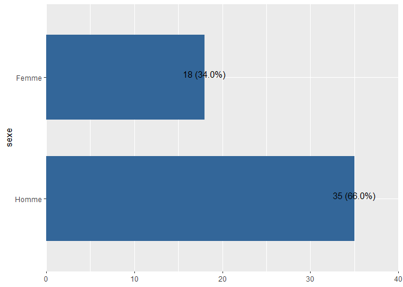

```r
 graphe <- sjPlot::plot_frq(base_tp2, coord.flip = TRUE, sexe)
 show(graphe)
```

Les résultats de l’étude montrent que la majeur partie (66,0%) des individus de la base sont des hommes.

### 3.1.2 Statistique sur l’age

```r
summary(base_tp2$age)
```

```
##    Min. 1st Qu.  Median    Mean 3rd Qu.    Max.
##    24.0    39.0    49.0    48.6    58.0    80.0
```

L’analyse des résultats laisse apparaitre que l’age moyen de la population étudiée est de 48 ans, l’age minimun est de 24 ans alors que l’age maximum est de 80 ans. La moitié des individus de notre population a au moins 49 ans.

### 3.1.3 Situation matrimoniale

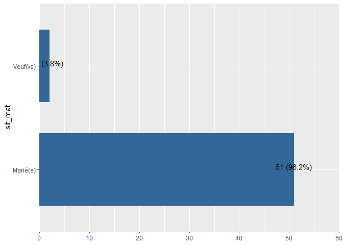

```r
graphe <- sjPlot::plot_frq(base_tp2, coord.flip = TRUE, sit_mat)
 show(graphe)
```

Les résultats montrent que seul les veuf(ve)s et les marié(e)s sont représentés sur la base avec des proportions respectives de 3,8% et de 96,2%.

### 3.1.4 Situation chef de ménage

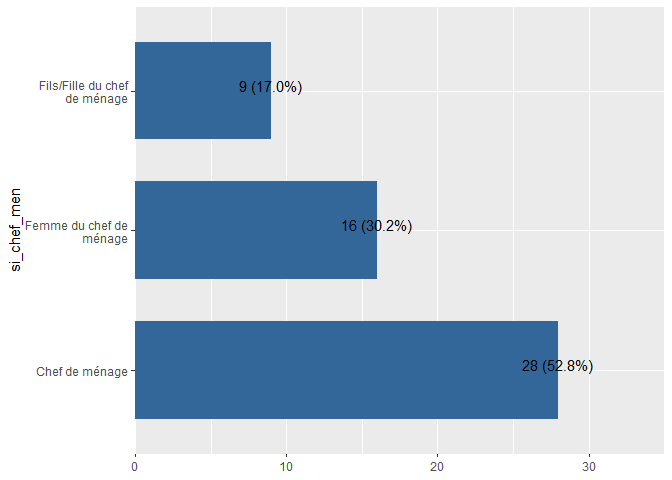

```r
graphe <- sjPlot::plot_frq(base_tp2, coord.flip = TRUE, si_chef_men)
show(graphe)
```

### 3.1.5 Répartition des ethnies

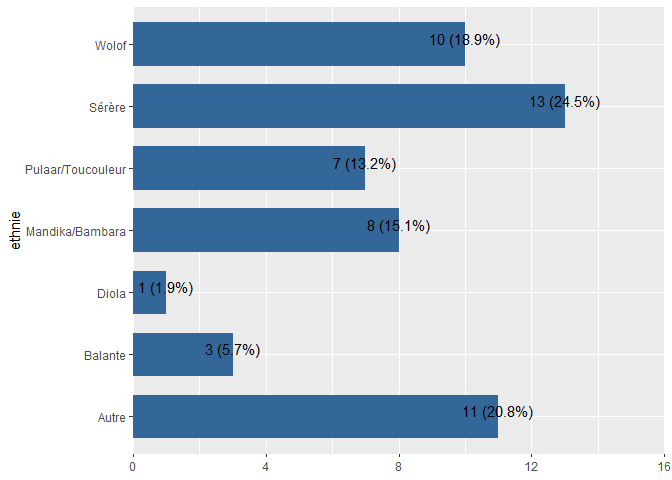

```r
graphe <- sjPlot::plot_frq(base_tp2, coord.flip = TRUE, ethnie)
show(graphe)
```

En ce qui concerne la répartion selon l’ethnie, 24,5% de la population d’étude sont des sérères, il s’en suit les wolofs, les Mandika et Bambara et les Toucouleurs avec des taux respectifs de 18,9%, 15,1% et 13,2%.

### 3.1.6 Répartition du niveau d’éducation du chef de ménage

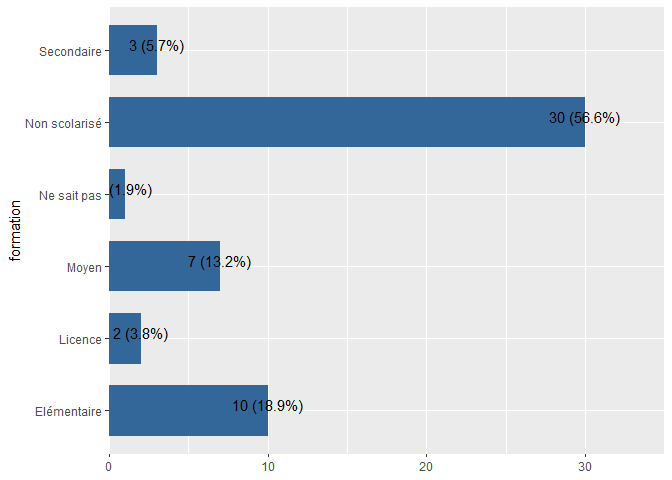

```r
graphe <- sjPlot::plot_frq(base_tp2, coord.flip = TRUE, formation)
show(graphe)
```

Les résultats de l’étude montrent que la majeur partie (56,6%) des chefs de ménage sont non scolarisé, 18,9% sont de niveau élémentaire et 13,2% sont de niveau moyen.

### 3.1.7 Répartition du niveau alphabétisation du chef de ménage

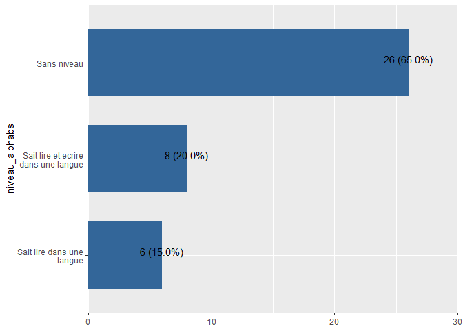

```r
graphe <- sjPlot::plot_frq(base_tp2, coord.flip = TRUE, niveau_alphabs)
show(graphe)
```

65,0% des chefs de ménage sont sans niveau d’alphabétisation, 20,0% savent lire et écrire dans une langue et les 15% restant savent lire dans une langue.

## 3.2 types de variété des produits

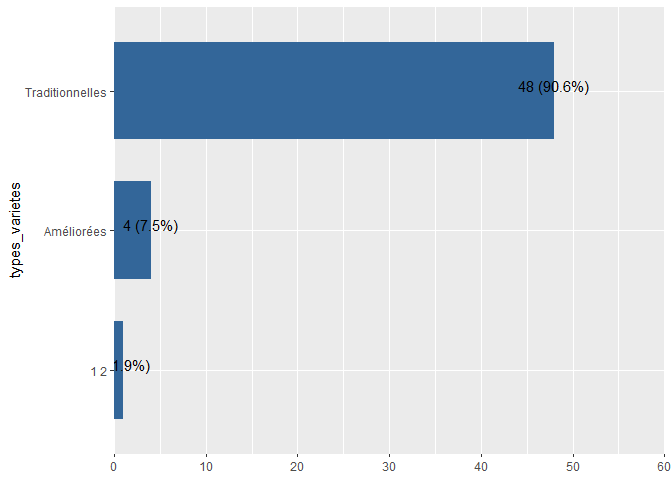

```r
graphe <- sjPlot::plot_frq(base_tp2, coord.flip = TRUE, types_varietes)
show(graphe)
```

En ce qui concerne les variétés, 90,6% sont de types traditionnels.

## 3.3 Statistiques bivariées

### 3.3.1 Sexe et situation matrimaniale

```r
base_tp2 %>%
tbl_cross(row = "sexe", col = "sit_mat", percent = "row")
```

|  | sit_mat Marié(e) | sit_mat Veuf(ve) | Total |  |
| --- | --- | --- | --- | --- |
| sexe |  |  |  |  |
| Homme | 35 (100%) | 0 (0%) | 35 (100%) |  |
| Femme | 16 (89%) | 2 (11%) | 18 (100%) |  |
| Total | 51 (96%) | 2 (3.8%) | 53 (100%) |  |

```r
### Tableau avec Kable

#  le tableau croisé
tab_crois <- table(base_tp2$sexe, base_tp2$sit_mat)

# tableau en pourcentages
tab_crois <- prop.table(table(base_tp2$sexe, base_tp2$sit_mat), margin = 1) * 100
# Affichage du tableau avec kable
kable(tab_crois,
      caption = "Répartition sexe et situation matrimoniale") %>%
  kable_styling(bootstrap_options = c("striped", "hover", "condensed", "responsive"),
                full_width = FALSE)
```

Répartition sexe et situation matrimoniale

|  | Marié(e) | Veuf(ve) |
| --- | --- | --- |
| Homme | 100.00000 | 0.00000 |
| Femme | 88.88889 | 11.11111 |

Les résultats montrent que tous les hommes enquetes sont des mariés tandus que pour les femmes seulement 89,0% sont des mariées.

### 3.3.2 Répartition des ages selon le sexe

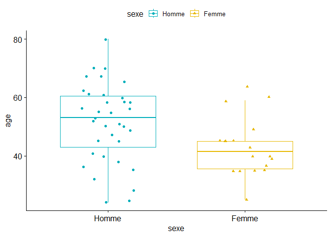

```r
library(ggpubr)

ggboxplot(base_tp2,
x = "sexe", y = "age",
color = "sexe", palette = c("#00AFBB", "#E7B800", "#FC4E07"),
add = "jitter", shape = "sexe"
)
```

### Situation matrimoniale et ethnie

```r
base_tp2 %>%
tbl_cross(row = "ethnie", col = "sit_mat", percent = "row")
```

|  | sit_mat Marié(e) | sit_mat Veuf(ve) | Total |  |
| --- | --- | --- | --- | --- |
| ethnie |  |  |  |  |
| Autre | 9 (82%) | 2 (18%) | 11 (100%) |  |
| Balante | 3 (100%) | 0 (0%) | 3 (100%) |  |
| Diola | 1 (100%) | 0 (0%) | 1 (100%) |  |
| Mandika/Bambara | 8 (100%) | 0 (0%) | 8 (100%) |  |
| Pulaar/Toucouleur | 7 (100%) | 0 (0%) | 7 (100%) |  |
| Sérère | 13 (100%) | 0 (0%) | 13 (100%) |  |
| Wolof | 10 (100%) | 0 (0%) | 10 (100%) |  |
| Total | 51 (96%) | 2 (3.8%) | 53 (100%) |  |

### 3.3.3 Formation et ethnie

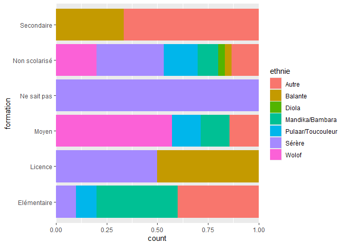

```r
  ggplot(base_tp2) +
aes(x = formation, fill = ethnie) +
  coord_flip() +
  scale_x_discrete(labels = scales::label_wrap(50)) +
scale_y_continuous(expand = c(0, 0)) +
geom_bar(position = "fill")
```

### 3.3.4 formation et sexe

```r
library(questionr)
tab <- table(base_tp2$sexe, base_tp2$formation)
lprop(tab)
```

```
##
##            Elémentaire Licence Moyen Ne sait pas Non scolarisé Secondaire Total
##   Homme     22.9         5.7    14.3   2.9        48.6           5.7      100.0
##   Femme     11.1         0.0    11.1   0.0        72.2           5.6      100.0
##   Ensemble  18.9         3.8    13.2   1.9        56.6           5.7      100.0
```